# SECTION 0: Setup & Imports

```python
import pandas as pd
import numpy as np
import os
```

```python
from google.colab import drive
drive.mount('/content/gdrive', force_remount=True)
```

# SECTION 1: Data Loading

```python
# The verified base path
base_path = "/content/gdrive/MyDrive/Stevens IT/Semester 2/BIA 810 - Healthcare Analytics/BIA 810 final project/Data"

# 1. Load all Medicare Claims parts into a list and concatenate immediately
claims_files = [f"Medicare_Claims_data_part_{i}.csv" for i in range(1, 6)]
claims_all = pd.concat([pd.read_csv(os.path.join(base_path, f), dtype=str) for f in claims_files], ignore_index=True)

# 2. Define a dictionary for the mapping/demographic files for easy access
mapping_files = {
    'hcp': 'HCP_demographics_data.csv',
    'patient': 'Patient_demographics_data.csv',
    'zip': 'Zip_to_Territory_Mapping.csv',
    'diagnosis': 'Diagnosis_Code_Mapping.csv',
    'procedure': 'Procedure_Code_Mapping.csv'
}

# Load them into a dictionary of DataFrames
data = {key: pd.read_csv(os.path.join(base_path, val), dtype=str) for key, val in mapping_files.items()}

# 3. (Optional) Assign them to individual variables if you prefer the original names
hcp_demographics = data['hcp']
patient_demographics = data['patient']
territory_zip = data['zip']
diagnosis_code = data['diagnosis']
procedure_code = data['procedure']

print(f"✅ Setup Complete.")
print(f"Combined Claims Rows: {len(claims_all)}")
```

```
✅ Setup Complete.
Combined Claims Rows: 1000000
```

```python
claims_df = pd.concat([claims1, claims2, claims3, claims4, claims5], ignore_index=True)
print("Total rows:", claims_df.shape)
```

```
Total rows: (1000000, 17)
```

# SECTION 2: Data Cleaning & Column Renaming

```python
claims_df = claims_df.rename(columns={
    'cur_clm_uniq_id': 'claim_id',
    'bene_mbi_id': 'patient_id',
    'clm_from_dt': 'claim_date',
    'clm_dgns_cd': 'diagnosis_code',
    'clm_line_hcpcs_cd': 'procedure_code'
})
```

```python
claims_df['claim_date'] = pd.to_datetime(claims_df['claim_date'], errors='coerce')
```

```python
claims_df
```

|  | claim_id | patient_id | fac_prvdr_npi_num | claim_date | clm_thru_dt | prncpl_dgns_cd | clm_pmt_amt | clm_mdcr_instnl_tot_chrg_amt | clm_line_num | procedure_code | clm_line_cvrd_pd_amt | clm_val_sqnc_num_dgns | diagnosis_code | clm_val_sqnc_num_prcdr | clm_prcdr_cd | clm_line_alowd_chrg_amt | clm_prvdr_spclty_cd |
| --- | --- | --- | --- | --- | --- | --- | --- | --- | --- | --- | --- | --- | --- | --- | --- | --- | --- |
| 0 | 1272380 | 10791 | 1316539243.0 | 2016-11-08 | 11/7/2016 | S81811D | 154.73 | 11182.21567 | 11.0 | G8996 | -0.04 | 12.0 | Z951 | NaN | NaN | NaN | NaN |
| 1 | 631196 | 10107 | 1033201873.0 | 2016-07-21 | 7/12/2016 | S0083XA | NaN | NaN | 1.0 | 76700 | 2.57 | NaN | I10 | NaN | NaN | 8.86 | 69 |
| 2 | 1548564 | 10412 | 1880496824.0 | 2018-07-14 | 5/20/2018 | R918 | NaN | NaN | 1.0 | C1751 | 53.81 | NaN | I10 | NaN | NaN | 86.4 | 30 |
| 3 | 1427731 | 10934 | 1655569458.0 | 2016-06-19 | 7/15/2016 | I2119 | 705.89 | 20750.00517 | 17.0 | 85378 | -5.91 | 7.0 | M25552 | NaN | NaN | NaN | NaN |
| 4 | 428779 | 965 | 1644309286.0 | 2017-03-21 | 8/10/2018 | C4490 | 2884.15 | 18437.66432 | 5.0 | 80061 | 2.62 | 6.0 | Z9049 | NaN | NaN | NaN | NaN |
| ... | ... | ... | ... | ... | ... | ... | ... | ... | ... | ... | ... | ... | ... | ... | ... | ... | ... |
| 999995 | 842577 | 27 | 2094818789.0 | 2016-07-15 | 4/22/2017 | Z01812 | 49.65 | 783.6576785 | 5.0 | J1885 | 4.83 | 4.0 | E785 | NaN | NaN | NaN | NaN |
| 999996 | 309023 | 11454 | 4138986079.0 | 2018-04-24 | 3/2/2018 | M40203 | NaN | NaN | 1.0 | J3010 | 47.4 | NaN | I10 | NaN | NaN | 76.03 | 1 |
| 999997 | 568041 | 10869 | 5314548510.0 | 2018-01-17 | 12/13/2017 | J432 | NaN | NaN | 2.0 | 17004 | 43.87 | NaN | I10 | NaN | NaN | 55.35 | 7 |
| 999998 | 100020 | 10784 | 5599719066.0 | 2016-12-23 | 1/20/2017 | I639 | NaN | NaN | 1.0 | J1030 | 3.92 | NaN | I10 | NaN | NaN | 15.02 | 8 |
| 999999 | 1645172 | 11429 | 7218513293.0 | 2017-07-28 | 9/30/2017 | R141 | 31.67 | 538.3300181 | 1.0 | A9561 | 136.82 | 4.0 | Z131 | NaN | NaN | NaN | NaN |

1000000 rows × 17 columns

# SECTION 3: Market Basket Filtering (Expected: 28,368 rows)

```python
market_procedure_codes = ['J1885', 'J2250', 'J2704', 'J3010']

# Step 1: Find all claim_ids that contain at least one market procedure code
market_claim_ids = claims_df.loc[claims_df['procedure_code'].isin(market_procedure_codes), 'claim_id'].unique()

# Step 2: Filter ALL records belonging to those claim_ids (not just the market code lines)
market_claims_df = claims_df[claims_df['claim_id'].isin(market_claim_ids)].copy()

print('Unique market claim IDs found:', len(market_claim_ids))
print('Shape of filtered claims_df:', market_claims_df.shape)
```

```
Unique market claim IDs found: 15145
Shape of filtered claims_df: (28368, 17)
```

```python
market_claims_df
```

|  | claim_id | patient_id | fac_prvdr_npi_num | claim_date | clm_thru_dt | prncpl_dgns_cd | clm_pmt_amt | clm_mdcr_instnl_tot_chrg_amt | clm_line_num | procedure_code | clm_line_cvrd_pd_amt | clm_val_sqnc_num_dgns | diagnosis_code | clm_val_sqnc_num_prcdr | clm_prcdr_cd | clm_line_alowd_chrg_amt | clm_prvdr_spclty_cd |
| --- | --- | --- | --- | --- | --- | --- | --- | --- | --- | --- | --- | --- | --- | --- | --- | --- | --- |
| 971632 | 300876 | 12388 | 7348083745.0 | 2018-06-03 | 9/11/2018 | H16223 | NaN | NaN | 1.0 | J3010 | 36.07 | NaN | I10 | NaN | NaN | 51.01 | 11 |
| 971633 | 657288 | 11556 | 2202143437.0 | 2016-06-03 | 4/8/2016 | K2270 | NaN | 5872.483621 | 1.0 | J1885 | -3.97 | NaN | Z7901 | NaN | NaN | NaN | NaN |
| 971634 | 450553 | 12021 | 5004034153.0 | 2018-10-04 | 10/23/2018 | A4181 | 1559.76 | 3539.391284 | 31.0 | 99283 | 13.35 | 14.0 | K921 | NaN | NaN | NaN | NaN |
| 971635 | 277076 | 10815 | 4368806084.0 | 2016-12-12 | 9/1/2016 | C8300 | NaN | NaN | 4.0 | J3010 | 4.29 | NaN | I10 | NaN | NaN | 98.48 | 8 |
| 971636 | 476863 | 13224 | 5200262348.0 | 2016-06-21 | 11/5/2016 | L0889 | 79.61 | 699.9675131 | 2.0 | 80048 | 0.54 | 4.0 | Z9861 | NaN | NaN | NaN | NaN |
| ... | ... | ... | ... | ... | ... | ... | ... | ... | ... | ... | ... | ... | ... | ... | ... | ... | ... |
| 999995 | 842577 | 27 | 2094818789.0 | 2016-07-15 | 4/22/2017 | Z01812 | 49.65 | 783.6576785 | 5.0 | J1885 | 4.83 | 4.0 | E785 | NaN | NaN | NaN | NaN |
| 999996 | 309023 | 11454 | 4138986079.0 | 2018-04-24 | 3/2/2018 | M40203 | NaN | NaN | 1.0 | J3010 | 47.4 | NaN | I10 | NaN | NaN | 76.03 | 1 |
| 999997 | 568041 | 10869 | 5314548510.0 | 2018-01-17 | 12/13/2017 | J432 | NaN | NaN | 2.0 | 17004 | 43.87 | NaN | I10 | NaN | NaN | 55.35 | 7 |
| 999998 | 100020 | 10784 | 5599719066.0 | 2016-12-23 | 1/20/2017 | I639 | NaN | NaN | 1.0 | J1030 | 3.92 | NaN | I10 | NaN | NaN | 15.02 | 8 |
| 999999 | 1645172 | 11429 | 7218513293.0 | 2017-07-28 | 9/30/2017 | R141 | 31.67 | 538.3300181 | 1.0 | A9561 | 136.82 | 4.0 | Z131 | NaN | NaN | NaN | NaN |

28368 rows × 17 columns

```python
# Verify record count matches expected 28,368
print(f"Filtered market_claims_df shape: {market_claims_df.shape}")
assert market_claims_df.shape[0] == 28368, f"Expected 28368 rows, got {market_claims_df.shape[0]}"
```

```
Filtered market_claims_df shape: (28368, 17)
```

# SECTION 4: Joining Supplemental Datasets

```python
market_claims_df['claim_date'] = pd.to_datetime(market_claims_df['claim_date'], errors='coerce')
market_claims_df['claim_year'] = market_claims_df['claim_date'].dt.year

print(market_claims_df['claim_year'].value_counts().sort_index())
```

```
claim_year
2015       17
2016     7991
2017     9746
2018    10614
Name: count, dtype: int64
```

## 4a: HCP Demographics

```python
hcp_demographics
```

|  | HCP NPI ID | Address | City | State | ZIP Code | Specialty |
| --- | --- | --- | --- | --- | --- | --- |
| 0 | 8386928704 | 322 Roberts Drive Suite 888 | South Shannonton | AS | 67431 | Neurology |
| 1 | 3688956922 | 11734 Deanna Groves Suite 031 | Leviburgh | OK | 12405 | Anesthesiology |
| 2 | 5134290518 | 18686 Schwartz Streets | Shepherdstad | RI | 97054 | Neurology |
| 3 | 6740392080 | 410 Woodard Drive Suite 766 | East Calvinmouth | MA | 92138 | Gastroenterology |
| 4 | 1178012810 | 83203 Jimenez Village Apt. 548 | Griffinchester | WY | 48202 | Anesthesiology |
| ... | ... | ... | ... | ... | ... | ... |
| 1995 | 7648402660 | 1207 Olivia Via | Phillipfort | UT | 81154 | Anesthesiology |
| 1996 | 5530159315 | 86116 Mathews Track Suite 253 | Port Scott | TN | 07721 | Gastroenterology |
| 1997 | 2202122399 | 070 Monica Loop | Haydenmouth | MD | 98386 | Cardiology |
| 1998 | 6175046381 | 5842 George Roads Suite 456 | Changchester | GA | 98013 | Gastroenterology |
| 1999 | 2075389828 | 36286 Rodney Field | Stephenshire | ND | 53946 | Anesthesiology |

2000 rows × 6 columns

```python
market_claims_df['fac_prvdr_npi_num'] = (
    market_claims_df['fac_prvdr_npi_num']
    .str.strip()
    .str.replace(r'\.0$', '', regex=True)   # remove trailing .0 from float cast
    .str.zfill(10)                           # pad to 10 digits
)

hcp_demographics['HCP NPI ID'] = (
    hcp_demographics['HCP NPI ID']
    .str.strip()
    .str.zfill(10)
)
```

```python
market_claims_df = market_claims_df.merge(
    hcp_demographics,
    left_on='fac_prvdr_npi_num',
    right_on='HCP NPI ID',
    how='left'
)
```

```python
print('Shape after HCP join:', market_claims_df.shape)
```

```
Shape after HCP join: (28368, 24)
```

```python
market_claims_df
```

|  | claim_id | patient_id | fac_prvdr_npi_num | claim_date | clm_thru_dt | prncpl_dgns_cd | clm_pmt_amt | clm_mdcr_instnl_tot_chrg_amt | clm_line_num | procedure_code | ... | clm_prcdr_cd | clm_line_alowd_chrg_amt | clm_prvdr_spclty_cd | claim_year | HCP NPI ID | Address | City | State | ZIP Code | Specialty |
| --- | --- | --- | --- | --- | --- | --- | --- | --- | --- | --- | --- | --- | --- | --- | --- | --- | --- | --- | --- | --- | --- |
| 0 | 300876 | 12388 | 7348083745 | 2018-06-03 | 9/11/2018 | H16223 | NaN | NaN | 1.0 | J3010 | ... | NaN | 51.01 | 11 | 2018 | 7348083745 | 01683 Garcia Terrace | West Ronaldmouth | MH | 10164 | Anesthesiology |
| 1 | 657288 | 11556 | 2202143437 | 2016-06-03 | 4/8/2016 | K2270 | NaN | 5872.483621 | 1.0 | J1885 | ... | NaN | NaN | NaN | 2016 | 2202143437 | 698 Reynolds Lake | Petersonside | WI | 38050 | Anesthesiology |
| 2 | 450553 | 12021 | 5004034153 | 2018-10-04 | 10/23/2018 | A4181 | 1559.76 | 3539.391284 | 31.0 | 99283 | ... | NaN | NaN | NaN | 2018 | 5004034153 | 879 Paul Cove Suite 764 | Williamchester | WV | 20012 | Cardiology |
| 3 | 277076 | 10815 | 4368806084 | 2016-12-12 | 9/1/2016 | C8300 | NaN | NaN | 4.0 | J3010 | ... | NaN | 98.48 | 8 | 2016 | 4368806084 | 920 Christine Ways Apt. 006 | South Travis | AL | 51355 | Cardiology |
| 4 | 476863 | 13224 | 5200262348 | 2016-06-21 | 11/5/2016 | L0889 | 79.61 | 699.9675131 | 2.0 | 80048 | ... | NaN | NaN | NaN | 2016 | 5200262348 | 383 Jennings Corners Apt. 259 | Morrisshire | MT | 76859 | Anesthesiology |
| ... | ... | ... | ... | ... | ... | ... | ... | ... | ... | ... | ... | ... | ... | ... | ... | ... | ... | ... | ... | ... | ... |
| 28363 | 842577 | 27 | 2094818789 | 2016-07-15 | 4/22/2017 | Z01812 | 49.65 | 783.6576785 | 5.0 | J1885 | ... | NaN | NaN | NaN | 2016 | 2094818789 | 2663 Matthew Ferry Suite 639 | Lake Courtneyport | KS | 20913 | Gastroenterology |
| 28364 | 309023 | 11454 | 4138986079 | 2018-04-24 | 3/2/2018 | M40203 | NaN | NaN | 1.0 | J3010 | ... | NaN | 76.03 | 1 | 2018 | 4138986079 | 48246 Holly Course Apt. 630 | Grahamton | CO | 39564 | Anesthesiology |
| 28365 | 568041 | 10869 | 5314548510 | 2018-01-17 | 12/13/2017 | J432 | NaN | NaN | 2.0 | 17004 | ... | NaN | 55.35 | 7 | 2018 | 5314548510 | 36717 Jenkins Freeway | New Morgan | DC | 74136 | Cardiology |
| 28366 | 100020 | 10784 | 5599719066 | 2016-12-23 | 1/20/2017 | I639 | NaN | NaN | 1.0 | J1030 | ... | NaN | 15.02 | 8 | 2016 | 5599719066 | 845 Garcia Mount | Williamberg | VT | 04765 | Anesthesiology |
| 28367 | 1645172 | 11429 | 7218513293 | 2017-07-28 | 9/30/2017 | R141 | 31.67 | 538.3300181 | 1.0 | A9561 | ... | NaN | NaN | NaN | 2017 | 7218513293 | 162 Evans Rapid Suite 693 | North Kimberly | KS | 27325 | Gastroenterology |

28368 rows × 24 columns

## 4b: Patient Demographics

```python
patient_demographics
```

|  | Patient_id | Age | Gender |
| --- | --- | --- | --- |
| 0 | 10 | 71 | Male |
| 1 | 11 | 56 | Male |
| 2 | 12 | 65 | Female |
| 3 | 13 | 72 | Female |
| 4 | 14 | 77 | Female |
| ... | ... | ... | ... |
| 4503 | 13376 | 64 | Female |
| 4504 | 13377 | 60 | Male |
| 4505 | 13378 | 23 | Female |
| 4506 | 13379 | 90 | Female |
| 4507 | 13380 | 69 | Female |

4508 rows × 3 columns

```python
# Join patient demographics to filtered claims using Patient ID as key
market_claims_df = market_claims_df.merge(
    patient_demographics,
    left_on='patient_id',
    right_on='Patient_id',
    how='left'
)

print('Shape after Patient join:', market_claims_df.shape)
```

```
Shape after Patient join: (28368, 27)
```

## 4c: Territory / ZIP Mapping

```python
territory_zip
```

|  | Zip Code | Territory Name | Region Name |
| --- | --- | --- | --- |
| 0 | 00501 | St Louis, MO | Midwest |
| 1 | 00544 | St Louis, MO | Midwest |
| 2 | 00601 | St Louis, MO | Midwest |
| 3 | 00602 | St Louis, MO | Midwest |
| 4 | 00603 | St Louis, MO | Midwest |
| ... | ... | ... | ... |
| 41678 | 99926 | Seattle, WA | West |
| 41679 | 99927 | Seattle, WA | West |
| 41680 | 99928 | Seattle, WA | West |
| 41681 | 99929 | Seattle, WA | West |
| 41682 | 99950 | Seattle, WA | West |

41683 rows × 3 columns

```python
market_claims_df['ZIP Code'] = (
    market_claims_df['ZIP Code']
    .astype(str)
    .str.strip()
    .str.zfill(5)
)

territory_zip['Zip Code'] = (
    territory_zip['Zip Code']
    .astype(str)
    .str.strip()
    .str.zfill(5)
)
```

```python
market_claims_df = market_claims_df.merge(
    territory_zip,
    left_on='ZIP Code',
    right_on='Zip Code',
    how='left'
)

print('Shape after Territory join:', market_claims_df.shape)
```

```
Shape after Territory join: (28368, 30)
```

```python
market_claims_df
```

|  | claim_id | patient_id | fac_prvdr_npi_num | claim_date | clm_thru_dt | prncpl_dgns_cd | clm_pmt_amt | clm_mdcr_instnl_tot_chrg_amt | clm_line_num | procedure_code | ... | City | State | ZIP Code | Specialty | Patient_id | Age | Gender | Zip Code | Territory Name | Region Name |
| --- | --- | --- | --- | --- | --- | --- | --- | --- | --- | --- | --- | --- | --- | --- | --- | --- | --- | --- | --- | --- | --- |
| 0 | 300876 | 12388 | 7348083745 | 2018-06-03 | 9/11/2018 | H16223 | NaN | NaN | 1.0 | J3010 | ... | West Ronaldmouth | MH | 10164 | Anesthesiology | 12388 | 18 | Female | 10164 | St Louis, MO | Midwest |
| 1 | 657288 | 11556 | 2202143437 | 2016-06-03 | 4/8/2016 | K2270 | NaN | 5872.483621 | 1.0 | J1885 | ... | Petersonside | WI | 38050 | Anesthesiology | 11556 | 61 | Female | 38050 | Orlando, FL | Southeast |
| 2 | 450553 | 12021 | 5004034153 | 2018-10-04 | 10/23/2018 | A4181 | 1559.76 | 3539.391284 | 31.0 | 99283 | ... | Williamchester | WV | 20012 | Cardiology | 12021 | 26 | Male | 20012 | Washington, D.C. | Northeast |
| 3 | 277076 | 10815 | 4368806084 | 2016-12-12 | 9/1/2016 | C8300 | NaN | NaN | 4.0 | J3010 | ... | South Travis | AL | 51355 | Cardiology | 10815 | 65 | Male | 51355 | New York, NY | Northeast |
| 4 | 476863 | 13224 | 5200262348 | 2016-06-21 | 11/5/2016 | L0889 | 79.61 | 699.9675131 | 2.0 | 80048 | ... | Morrisshire | MT | 76859 | Anesthesiology | 13224 | 37 | Female | 76859 | Charlotte, NC | Southeast |
| ... | ... | ... | ... | ... | ... | ... | ... | ... | ... | ... | ... | ... | ... | ... | ... | ... | ... | ... | ... | ... | ... |
| 28363 | 842577 | 27 | 2094818789 | 2016-07-15 | 4/22/2017 | Z01812 | 49.65 | 783.6576785 | 5.0 | J1885 | ... | Lake Courtneyport | KS | 20913 | Gastroenterology | 27 | 75 | Female | 20913 | Washington, D.C. | Northeast |
| 28364 | 309023 | 11454 | 4138986079 | 2018-04-24 | 3/2/2018 | M40203 | NaN | NaN | 1.0 | J3010 | ... | Grahamton | CO | 39564 | Anesthesiology | 11454 | 84 | Female | 39564 | Orlando, FL | Southeast |
| 28365 | 568041 | 10869 | 5314548510 | 2018-01-17 | 12/13/2017 | J432 | NaN | NaN | 2.0 | 17004 | ... | New Morgan | DC | 74136 | Cardiology | 10869 | 82 | Female | 74136 | LA-San Diego, CA | West |
| 28366 | 100020 | 10784 | 5599719066 | 2016-12-23 | 1/20/2017 | I639 | NaN | NaN | 1.0 | J1030 | ... | Williamberg | VT | 04765 | Anesthesiology | 10784 | 33 | Male | 04765 | Pittsburg, PA | Northeast |
| 28367 | 1645172 | 11429 | 7218513293 | 2017-07-28 | 9/30/2017 | R141 | 31.67 | 538.3300181 | 1.0 | A9561 | ... | North Kimberly | KS | 27325 | Gastroenterology | 11429 | 73 | Male | 27325 | Houston, TX | Southeast |

28368 rows × 30 columns

## 4d: Diagnosis Code Mapping

```python
diagnosis_code
```

|  | Diagnosis Code Market | Specialty |
| --- | --- | --- |
| 0 | A | Infectious and Parasitic Diseases |
| 1 | B | Infectious and Parasitic Diseases |
| 2 | C | Neoplasms |
| 3 | D | Neoplasms, Blood, Blood-forming Organs |
| 4 | E | Endocrine, Nutritional, Metabolic |
| 5 | F | Mental and Behavioral Disorders |
| 6 | G | Nervous System |
| 7 | H | Eye and Adnexa, Ear and Mastoid Process |
| 8 | I | Circulatory System |
| 9 | J | Respiratory System |
| 10 | K | Digestive System |
| 11 | L | Skin and Subcutaneous Tissue |
| 12 | M | Musculoskeletal and Connective Tissue |
| 13 | N | Genitourinary System |
| 14 | O | Pregnancy, Childbirth and the Puerperium |
| 15 | P | Certain Conditions Originating in the Perinata... |
| 16 | Q | Congenital Malformations, Deformations and Chr... |
| 17 | R | Symptoms, Signs and Abnormal Clinical and Lab ... |
| 18 | S | Injury, Poisoning, Certain Other Consequences ... |
| 19 | T | Injury, Poisoning, Certain Other Consequences ... |
| 20 | U | Codes for special purposes |
| 21 | V | External Causes of Morbidity |
| 22 | W | External Causes of Morbidity |
| 23 | X | External Causes of Morbidity |
| 24 | Y | External Causes of Morbidity |
| 25 | Z | Factors Influencing Health Status and Contact ... |

```python
# Extract the first character of the diagnosis code as the mapping key
market_claims_df['diag_initial'] = (
    market_claims_df['diagnosis_code']
    .str.strip()
    .str.upper()
    .str[0]
)

# Standardise the diagnosis code mapping key
diagnosis_code['Diagnosis Code Market'] = (
    diagnosis_code['Diagnosis Code Market']
    .str.strip()
    .str.upper()
)
```

```python
# Join diagnosis specialty mapping using initial alphabet as key
market_claims_df = market_claims_df.merge(
    diagnosis_code,
    left_on='diag_initial',
    right_on='Diagnosis Code Market',
    how='left'
)

print('Shape after Diagnosis Specialty join:', market_claims_df.shape)
```

```
Shape after Diagnosis Specialty join: (28368, 33)
```

```python
# Product label mapping
product_map = {
    'J1885': 'Product 1 (Ketorolac)',
    'J2250': 'Product 2 (Midazolam)',
    'J3010': 'Product 3 (Fentanyl)',
    'J2704': 'Product 4 (Propofol)'
}

# Filter to only market procedure code rows and years 2016-2018
market_df = market_claims_df[
    market_claims_df['procedure_code'].isin(product_map.keys()) &
    market_claims_df['claim_year'].isin([2016, 2017, 2018])
].copy()

market_df['product'] = market_df['procedure_code'].map(product_map)

print('Shape of market analysis df:', market_df.shape)
```

```
Shape of market analysis df: (15262, 34)
```

# SECTION 5: KBQ Analysis

## KBQ 1: Market Dynamics & Competitive Landscape

### KBQ 1a: Claims, Patient, and HCP Share

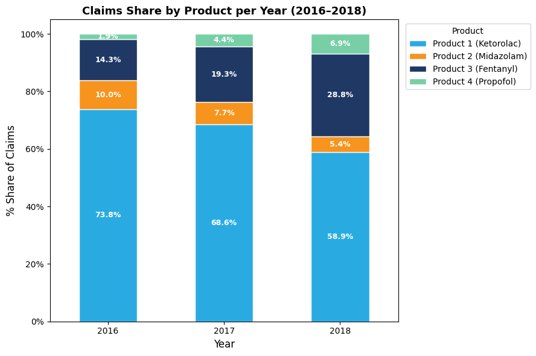

```python
#KBQ1
import matplotlib.pyplot as plt
import matplotlib.ticker as mtick

# ── Claims share ──────────────────────────────────────────────────────────────
claims_by_year_product = (
    market_df.groupby(['claim_year', 'product'])['claim_id']
    .count()
    .reset_index(name='claims')
)

claims_pivot = claims_by_year_product.pivot(index='claim_year', columns='product', values='claims').fillna(0)
claims_pct   = claims_pivot.div(claims_pivot.sum(axis=1), axis=0) * 100

# Updated with your specific palette
colors = ['#29ABE2', '#F7941D', '#1F3864', '#77CFA6']
ax = claims_pct.plot(kind='bar', stacked=True, figsize=(9, 6), color=colors, edgecolor='white')

ax.yaxis.set_major_formatter(mtick.PercentFormatter())
ax.set_xlabel('Year', fontsize=12)
ax.set_ylabel('% Share of Claims', fontsize=12)
ax.set_title('Claims Share by Product per Year (2016–2018)', fontsize=13, fontweight='bold')
ax.set_xticklabels([2016, 2017, 2018], rotation=0)
ax.legend(title='Product', bbox_to_anchor=(1.01, 1), loc='upper left')

# Add percentage labels inside bars
for bar_container in ax.containers:
    ax.bar_label(bar_container, fmt='%.1f%%', label_type='center', fontsize=9, color='white', fontweight='bold')

plt.tight_layout()
plt.savefig('kbq1_claims_share.png', dpi=150, bbox_inches='tight')
plt.show()
```

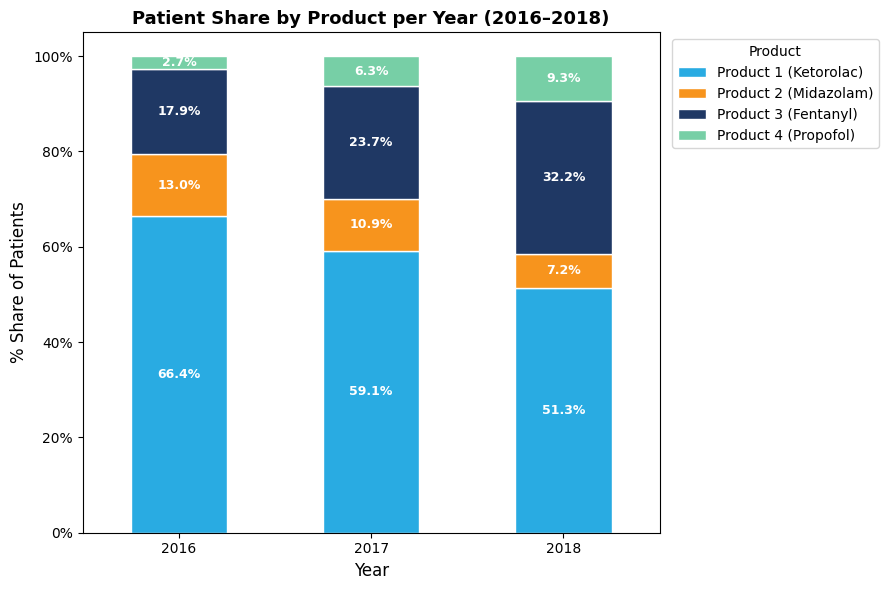

```python
# ── Unique Patients share ─────────────────────────────────────────────────────
patients_by_year_product = (
    market_df.groupby(['claim_year', 'product'])['patient_id']
    .nunique()
    .reset_index(name='patients')
)

patients_pivot = patients_by_year_product.pivot(index='claim_year', columns='product', values='patients').fillna(0)
patients_pct   = patients_pivot.div(patients_pivot.sum(axis=1), axis=0) * 100

# Using the first four colors of your palette
colors = ['#29ABE2', '#F7941D', '#1F3864', '#77CFA6']
ax = patients_pct.plot(kind='bar', stacked=True, figsize=(9, 6), color=colors, edgecolor='white')

ax.yaxis.set_major_formatter(mtick.PercentFormatter())
ax.set_xlabel('Year', fontsize=12)
ax.set_ylabel('% Share of Patients', fontsize=12)
ax.set_title('Patient Share by Product per Year (2016–2018)', fontsize=13, fontweight='bold')
ax.set_xticklabels([2016, 2017, 2018], rotation=0)
ax.legend(title='Product', bbox_to_anchor=(1.01, 1), loc='upper left')

for bar_container in ax.containers:
    ax.bar_label(bar_container, fmt='%.1f%%', label_type='center', fontsize=9, color='white', fontweight='bold')

plt.tight_layout()
plt.savefig('kbq1_patients_share.png', dpi=150, bbox_inches='tight')
plt.show()
```

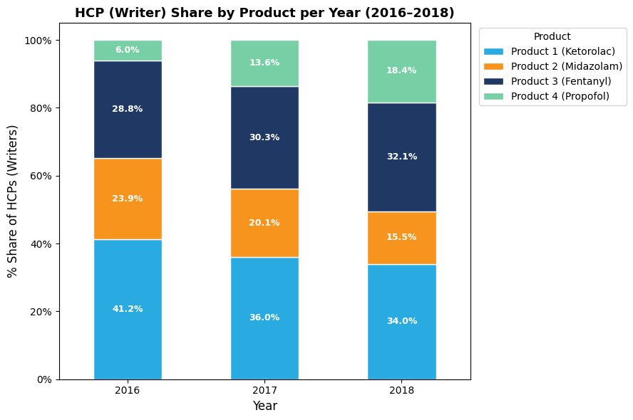

```python
# ── Unique HCPs (Writers) share ───────────────────────────────────────────────
hcps_by_year_product = (
    market_df.groupby(['claim_year', 'product'])['fac_prvdr_npi_num']
    .nunique()
    .reset_index(name='hcps')
)

hcps_pivot = hcps_by_year_product.pivot(index='claim_year', columns='product', values='hcps').fillna(0)
hcps_pct   = hcps_pivot.div(hcps_pivot.sum(axis=1), axis=0) * 100

# Updated with your specific palette
colors = ['#29ABE2', '#F7941D', '#1F3864', '#77CFA6']
ax = hcps_pct.plot(kind='bar', stacked=True, figsize=(9, 6), color=colors, edgecolor='white')

ax.yaxis.set_major_formatter(mtick.PercentFormatter())
ax.set_xlabel('Year', fontsize=12)
ax.set_ylabel('% Share of HCPs (Writers)', fontsize=12)
ax.set_title('HCP (Writer) Share by Product per Year (2016–2018)', fontsize=13, fontweight='bold')
ax.set_xticklabels([2016, 2017, 2018], rotation=0)
ax.legend(title='Product', bbox_to_anchor=(1.01, 1), loc='upper left')

for bar_container in ax.containers:
    ax.bar_label(bar_container, fmt='%.1f%%', label_type='center', fontsize=9, color='white', fontweight='bold')

plt.tight_layout()
plt.savefig('kbq1_hcps_share.png', dpi=150, bbox_inches='tight')
plt.show()
```

### KBQ 1b: Claims per Writer / Patients per Writer

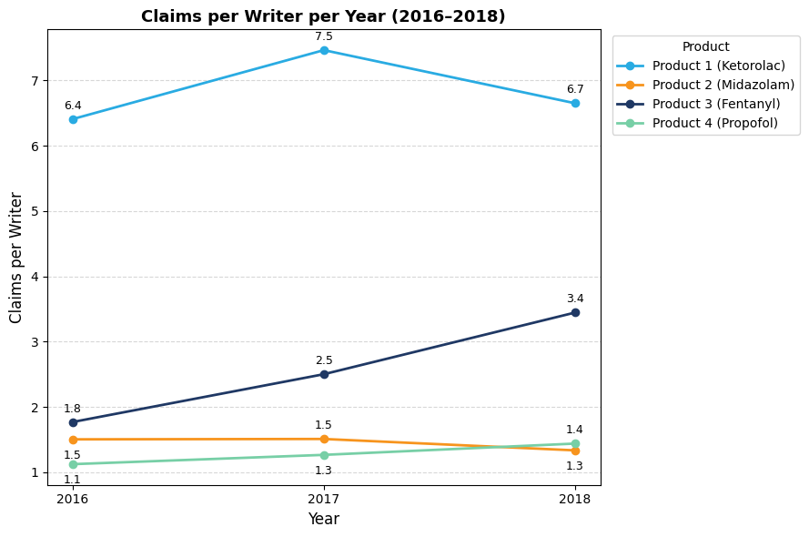

```python
# ── Claims per Writer ─────────────────────────────────────────────────────────
claims_per_writer = (
    market_df.groupby(['claim_year', 'product'])
    .agg(total_claims=('claim_id', 'count'),
         total_writers=('fac_prvdr_npi_num', 'nunique'))
    .reset_index()
)
claims_per_writer['claims_per_writer'] = (
    claims_per_writer['total_claims'] / claims_per_writer['total_writers']
)

# Fine-tuned offsets for every product at every year
label_offsets = {
    'Product 1 (Ketorolac)' : {2016: (0, 8),   2017: (0, 8),   2018: (0, 8)},
    'Product 2 (Midazolam)' : {2016: (0, -15), 2017: (0, 8),   2018: (0, -15)},
    'Product 3 (Fentanyl)'  : {2016: (0, 8),   2017: (0, 8),   2018: (0, 8)},
    'Product 4 (Propofol)'  : {2016: (0, -15), 2017: (0, -15), 2018: (0, 8)},
}

# Updated palette application
colors = ['#29ABE2', '#F7941D', '#1F3864', '#77CFA6']

fig, ax = plt.subplots(figsize=(9, 6))

# Map products to colors to ensure consistent coloring
product_list = claims_per_writer['product'].unique()
color_map = {product: colors[i % len(colors)] for i, product in enumerate(product_list)}

for product, grp in claims_per_writer.groupby('product'):
    grp_sorted = grp.sort_values('claim_year')
    ax.plot(grp_sorted['claim_year'], grp_sorted['claims_per_writer'],
            marker='o', linewidth=2, label=product, color=color_map[product])

    for _, row in grp_sorted.iterrows():
        xytext = label_offsets[product][row['claim_year']]
        ax.annotate(f"{row['claims_per_writer']:.1f}",
                    (row['claim_year'], row['claims_per_writer']),
                    textcoords='offset points',
                    xytext=xytext,
                    ha='center', fontsize=9)

ax.set_xlabel('Year', fontsize=12)
ax.set_ylabel('Claims per Writer', fontsize=12)
ax.set_title('Claims per Writer per Year (2016–2018)', fontsize=13, fontweight='bold')
ax.set_xticks([2016, 2017, 2018])
ax.legend(title='Product', bbox_to_anchor=(1.01, 1), loc='upper left')
ax.grid(axis='y', linestyle='--', alpha=0.5)

plt.tight_layout()
plt.savefig('kbq1_claims_per_writer.png', dpi=150, bbox_inches='tight')
plt.show()
```

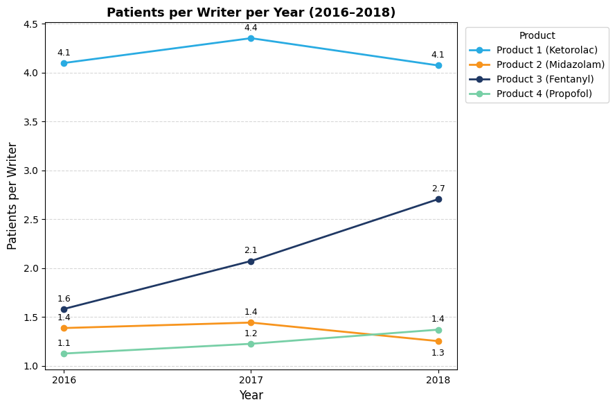

```python
# ── Patients per Writer ───────────────────────────────────────────────────────
patients_per_writer = (
    market_df.groupby(['claim_year', 'product'])
    .agg(total_patients=('patient_id', 'nunique'),
         total_writers=('fac_prvdr_npi_num', 'nunique'))
    .reset_index()
)
patients_per_writer['patients_per_writer'] = (
    patients_per_writer['total_patients'] / patients_per_writer['total_writers']
)

# New color palette
colors = ['#29ABE2', '#F7941D', '#1F3864', '#77CFA6']

fig, ax = plt.subplots(figsize=(9, 6))

# Map colors consistently across the groups
product_list = patients_per_writer['product'].unique()
color_map = {product: colors[i % len(colors)] for i, product in enumerate(product_list)}

for product, grp in patients_per_writer.groupby('product'):
    grp_sorted = grp.sort_values('claim_year')
    ax.plot(grp_sorted['claim_year'], grp_sorted['patients_per_writer'],
            marker='o', linewidth=2, label=product, color=color_map[product])

    for _, row in grp_sorted.iterrows():
        # Apply special offsets only at 2018 for the overlapping products
        if row['claim_year'] == 2018 and product == 'Product 2 (Midazolam)':
            xytext = (0, -15)  # push below
        elif row['claim_year'] == 2018 and product == 'Product 4 (Propofol)':
            xytext = (0, 8)    # push above
        else:
            xytext = (0, 8)    # default

        ax.annotate(f"{row['patients_per_writer']:.1f}",
                    (row['claim_year'], row['patients_per_writer']),
                    textcoords='offset points',
                    xytext=xytext,
                    ha='center', fontsize=9)

ax.set_xlabel('Year', fontsize=12)
ax.set_ylabel('Patients per Writer', fontsize=12)
ax.set_title('Patients per Writer per Year (2016–2018)', fontsize=13, fontweight='bold')
ax.set_xticks([2016, 2017, 2018])
ax.legend(title='Product', bbox_to_anchor=(1.01, 1), loc='upper left')
ax.grid(axis='y', linestyle='--', alpha=0.5)

plt.tight_layout()
plt.savefig('kbq1_patients_per_writer.png', dpi=150, bbox_inches='tight')
plt.show()
```

### KBQ 1c: Top 5 Declining Territories

```python
# ── Territory-level claims volume per product per year ────────────────────────
territory_claims = (
    market_df.groupby(['Territory Name', 'claim_year', 'product'])['claim_id']
    .count()
    .reset_index(name='claims')
)

# Filter for Product 2 (Midazolam - J2250)
p2_territory = territory_claims[territory_claims['product'] == 'Product 2 (Midazolam)'].copy()
p2_pivot = p2_territory.pivot(index='Territory Name', columns='claim_year', values='claims').fillna(0)

# YoY change % from 2017 to 2018
p2_pivot['yoy_pct'] = ((p2_pivot[2018] - p2_pivot[2017]) / p2_pivot[2017].replace(0, 1)) * 100

# Sort and get top 5 with biggest drop
top5_territories = p2_pivot.sort_values('yoy_pct').head(5).index.tolist()
print('Top 5 territories with biggest drop in Product 2 claims (2017→2018):')
print(p2_pivot.loc[top5_territories, [2016, 2017, 2018, 'yoy_pct']].round(1))
```

```
Top 5 territories with biggest drop in Product 2 claims (2017→2018):
claim_year        2016  2017  2018  yoy_pct
Territory Name
St Louis, MO        19    22     6    -72.7
Phoenix, AZ         11    10     3    -70.0
LA-San Diego, CA    29    38    16    -57.9
New York, NY        24    40    17    -57.5
Minneapolis, MN     15    15     7    -53.3
```

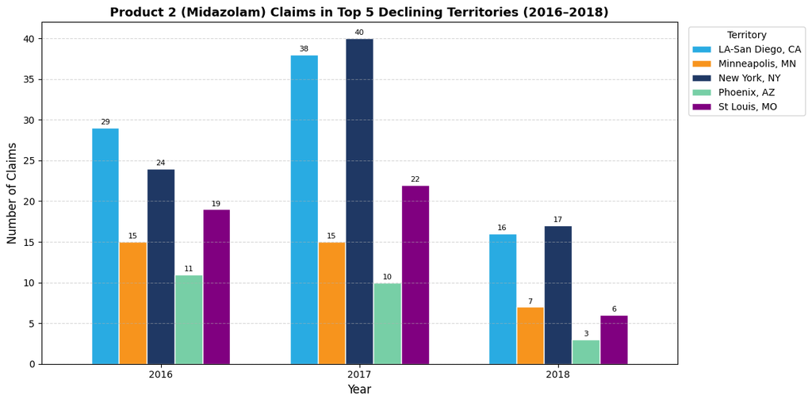

```python
# ── Clustered bar — Product 2 in top 5 territories ───────────────────────────
p2_top5 = territory_claims[
    (territory_claims['product'] == 'Product 2 (Midazolam)') &
    (territory_claims['Territory Name'].isin(top5_territories))
]

p2_top5_pivot = p2_top5.pivot(index='claim_year', columns='Territory Name', values='claims').fillna(0)

# Updated palette with Purple as the fifth color
colors = ['#29ABE2', '#F7941D', '#1F3864', '#77CFA6', '#800080']
ax = p2_top5_pivot.plot(kind='bar', figsize=(12, 6), color=colors, edgecolor='white', width=0.7)

ax.set_xlabel('Year', fontsize=12)
ax.set_ylabel('Number of Claims', fontsize=12)
ax.set_title('Product 2 (Midazolam) Claims in Top 5 Declining Territories (2016–2018)',
             fontsize=13, fontweight='bold')
ax.set_xticklabels([2016, 2017, 2018], rotation=0)
ax.legend(title='Territory', bbox_to_anchor=(1.01, 1), loc='upper left')
ax.grid(axis='y', linestyle='--', alpha=0.5)

for bar_container in ax.containers:
    ax.bar_label(bar_container, fmt='%.0f', label_type='edge', fontsize=8, padding=2)

plt.tight_layout()
plt.savefig('kbq1_p2_top5_territories.png', dpi=150, bbox_inches='tight')
plt.show()
```

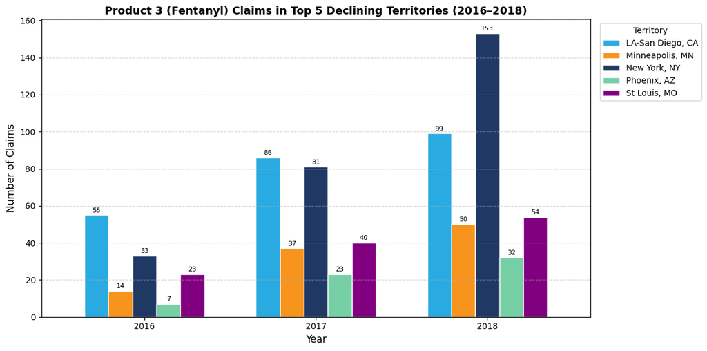

```python
# ── Clustered bar — Product 3 (Fentanyl) in same top 5 territories ────────────
p3_top5 = territory_claims[
    (territory_claims['product'] == 'Product 3 (Fentanyl)') &
    (territory_claims['Territory Name'].isin(top5_territories))
]

p3_top5_pivot = p3_top5.pivot(index='claim_year', columns='Territory Name', values='claims').fillna(0)

# Updated palette with Purple as the fifth color
colors = ['#29ABE2', '#F7941D', '#1F3864', '#77CFA6', '#800080']
ax = p3_top5_pivot.plot(kind='bar', figsize=(12, 6), color=colors, edgecolor='white', width=0.7)

ax.set_xlabel('Year', fontsize=12)
ax.set_ylabel('Number of Claims', fontsize=12)
ax.set_title('Product 3 (Fentanyl) Claims in Top 5 Declining Territories (2016–2018)',
             fontsize=13, fontweight='bold')
ax.set_xticklabels([2016, 2017, 2018], rotation=0)
ax.legend(title='Territory', bbox_to_anchor=(1.01, 1), loc='upper left')
ax.grid(axis='y', linestyle='--', alpha=0.5)

for bar_container in ax.containers:
    ax.bar_label(bar_container, fmt='%.0f', label_type='edge', fontsize=8, padding=2)

plt.tight_layout()
plt.savefig('kbq1_p3_top5_territories.png', dpi=150, bbox_inches='tight')
plt.show()
```

```python
print(market_df.columns.tolist())
```

[output not shown]

## KBQ 2: Key Market Drivers

### KBQ 2a: Diagnosis Specialty & HCP Specialty

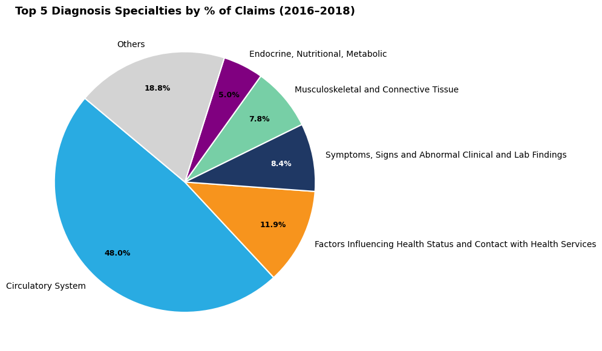

```python
# Specialty_y = Diagnosis Specialty (from Diagnosis Code Mapping)
diag_claims = (
    market_df.groupby('Specialty_y')['claim_id']
    .count()
    .reset_index(name='claims')
    .sort_values('claims', ascending=False)
)

top5_diag = diag_claims.head(5).copy()
other_claims = diag_claims.iloc[5:]['claims'].sum()
top5_diag = pd.concat([
    top5_diag,
    pd.DataFrame({'Specialty_y': ['Others'], 'claims': [other_claims]})
], ignore_index=True)

# Palette update: 5 specific colors + grey for 'Others'
pie_colors = ['#29ABE2', '#F7941D', '#1F3864', '#77CFA6', '#800080', '#D3D3D3']

fig, ax = plt.subplots(figsize=(9, 7))
wedges, texts, autotexts = ax.pie(
    top5_diag['claims'],
    labels=top5_diag['Specialty_y'],
    autopct='%1.1f%%',
    startangle=140,
    colors=pie_colors,
    pctdistance=0.75,
    wedgeprops={'edgecolor': 'white', 'linewidth': 1.5}
)

for text in autotexts:
    text.set_fontsize(9)
    text.set_fontweight('bold')
    # Optional: Make text white for better contrast on dark colors
    if text.get_text() in [autotexts[2].get_text()]: # Matches the dark navy wedge
        text.set_color('white')

ax.set_title('Top 5 Diagnosis Specialties by % of Claims (2016–2018)',
             fontsize=13, fontweight='bold')
plt.tight_layout()
plt.savefig('kbq2_diag_specialty_pie.png', dpi=150, bbox_inches='tight')
plt.show()
```

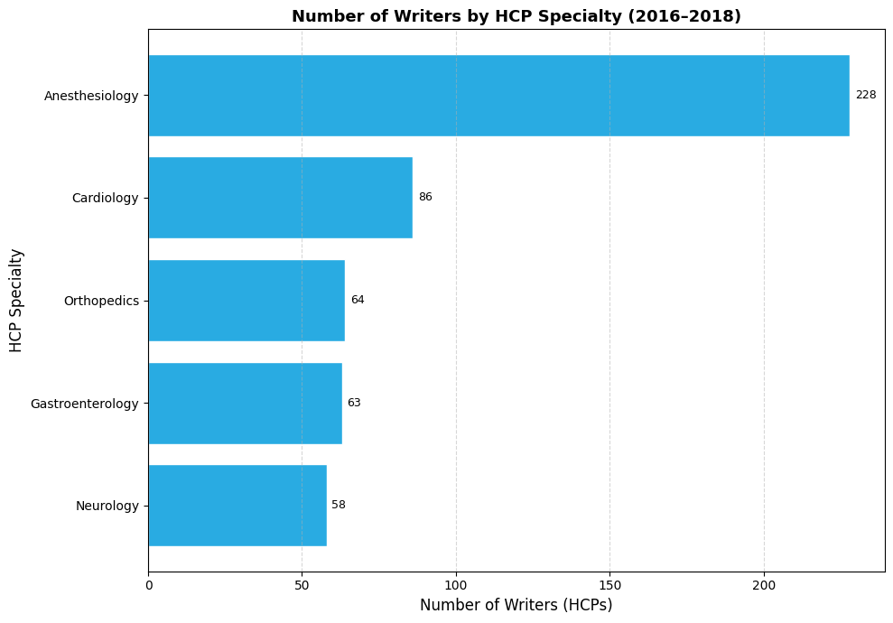

```python
# Specialty_x = HCP Specialty (from HCP Demographics)
hcp_specialty_writers = (
    market_df.groupby('Specialty_x')['fac_prvdr_npi_num']
    .nunique()
    .reset_index(name='writers')
    .sort_values('writers', ascending=True)
)

# Using the first color from your palette for the bars
primary_color = '#29ABE2'

fig, ax = plt.subplots(figsize=(10, 7))
bars = ax.barh(hcp_specialty_writers['Specialty_x'],
               hcp_specialty_writers['writers'],
               color=primary_color, edgecolor='white')

ax.bar_label(bars, fmt='%.0f', padding=4, fontsize=9)
ax.set_xlabel('Number of Writers (HCPs)', fontsize=12)
ax.set_ylabel('HCP Specialty', fontsize=12)
ax.set_title('Number of Writers by HCP Specialty (2016–2018)',
             fontsize=13, fontweight='bold')
ax.grid(axis='x', linestyle='--', alpha=0.5)

plt.tight_layout()
plt.savefig('kbq2_hcp_specialty_writers.png', dpi=150, bbox_inches='tight')
plt.show()
```

### KBQ 2b: Patient Age Distribution

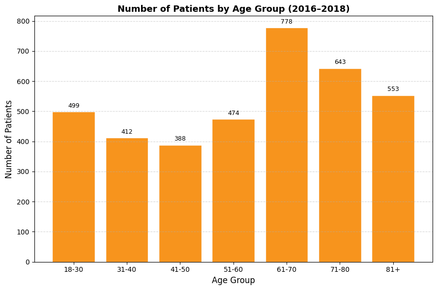

```python
# ── Patients by Age Group ─────────────────────────────────────────────────────
age_bins   = [17, 30, 40, 50, 60, 70, 80, 200]
age_labels = ['18-30', '31-40', '41-50', '51-60', '61-70', '71-80', '81+']

market_df['age_group'] = pd.cut(
    market_df['Age'].astype(float),
    bins=age_bins,
    labels=age_labels,
    right=True
)

patients_by_age = (
    market_df.groupby('age_group', observed=True)['patient_id']
    .nunique()
    .reset_index(name='patients')
)

# Using the first color from your palette (#29ABE2) to replace the green
primary_color = '#F7941D'

fig, ax = plt.subplots(figsize=(9, 6))
bars = ax.bar(patients_by_age['age_group'].astype(str),
              patients_by_age['patients'],
              color=primary_color, edgecolor='white')

ax.bar_label(bars, fmt='%.0f', padding=4, fontsize=9)
ax.set_xlabel('Age Group', fontsize=12)
ax.set_ylabel('Number of Patients', fontsize=12)
ax.set_title('Number of Patients by Age Group (2016–2018)',
             fontsize=13, fontweight='bold')
ax.grid(axis='y', linestyle='--', alpha=0.5)

plt.tight_layout()
plt.savefig('kbq2_patients_age_group.png', dpi=150, bbox_inches='tight')
plt.show()
```

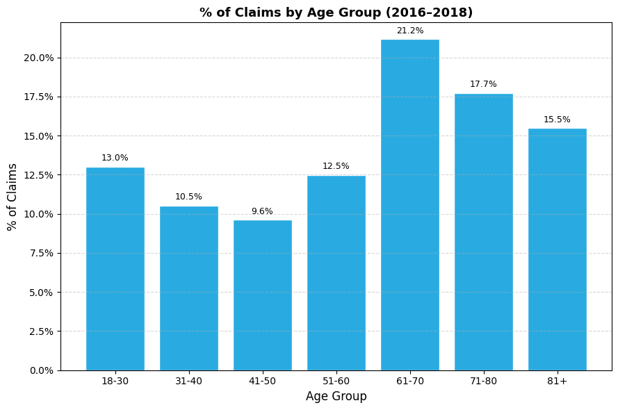

```python
# ── % of Claims by Age Group ──────────────────────────────────────────────────
claims_by_age = (
    market_df.groupby('age_group', observed=True)['claim_id']
    .count()
    .reset_index(name='claims')
)
claims_by_age['pct'] = claims_by_age['claims'] / claims_by_age['claims'].sum() * 100

# Using the first color from your palette (#29ABE2) to replace the orange
primary_color = '#29ABE2'

fig, ax = plt.subplots(figsize=(9, 6))
bars = ax.bar(claims_by_age['age_group'].astype(str),
              claims_by_age['pct'],
              color=primary_color, edgecolor='white')

ax.bar_label(bars, fmt='%.1f%%', padding=4, fontsize=9)
ax.set_xlabel('Age Group', fontsize=12)
ax.set_ylabel('% of Claims', fontsize=12)
ax.set_title('% of Claims by Age Group (2016–2018)',
             fontsize=13, fontweight='bold')
ax.yaxis.set_major_formatter(mtick.PercentFormatter())
ax.grid(axis='y', linestyle='--', alpha=0.5)

plt.tight_layout()
plt.savefig('kbq2_claims_age_group.png', dpi=150, bbox_inches='tight')
plt.show()
```

### KBQ 2c: New & Continuing Writer Trends

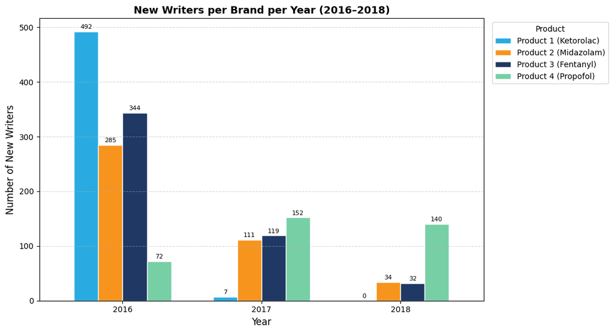

```python
# ── New Writers per Brand per Year ────────────────────────────────────────────
# For each HCP-product combo, find the first year they wrote that product
writer_first_year = (
    market_df.groupby(['fac_prvdr_npi_num', 'product'])['claim_year']
    .min()
    .reset_index(name='first_year')
)

# New writers = HCPs writing a product for the first time in that year
new_writers = (
    writer_first_year.groupby(['first_year', 'product'])['fac_prvdr_npi_num']
    .nunique()
    .reset_index(name='new_writers')
)
new_writers = new_writers[new_writers['first_year'].isin([2016, 2017, 2018])]

new_writers_pivot = new_writers.pivot(index='first_year', columns='product', values='new_writers').fillna(0)

# Updated with your specified palette (using the first 4 colors as per the data columns)
colors = ['#29ABE2', '#F7941D', '#1F3864', '#77CFA6']
ax = new_writers_pivot.plot(kind='bar', figsize=(11, 6), color=colors, edgecolor='white', width=0.7)

ax.set_xlabel('Year', fontsize=12)
ax.set_ylabel('Number of New Writers', fontsize=12)
ax.set_title('New Writers per Brand per Year (2016–2018)',
             fontsize=13, fontweight='bold')
ax.set_xticklabels([2016, 2017, 2018], rotation=0)
ax.legend(title='Product', bbox_to_anchor=(1.01, 1), loc='upper left')
ax.grid(axis='y', linestyle='--', alpha=0.5)

for bar_container in ax.containers:
    ax.bar_label(bar_container, fmt='%.0f', label_type='edge', fontsize=8, padding=2)

plt.tight_layout()
plt.savefig('kbq2_new_writers.png', dpi=150, bbox_inches='tight')
plt.show()
```

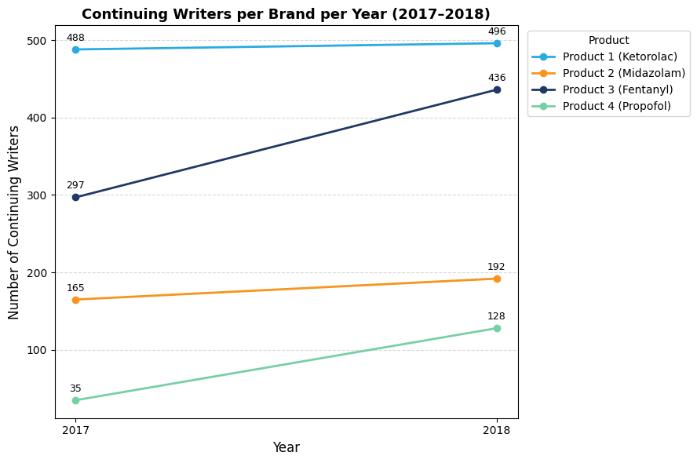

```python
# ── Continuing Writers per Brand per Year ─────────────────────────────────────
# Total writers per brand per year
total_writers = (
    market_df.groupby(['claim_year', 'product'])['fac_prvdr_npi_num']
    .nunique()
    .reset_index(name='total_writers')
)

# Merge new writers onto total writers
continuing = total_writers.merge(
    new_writers.rename(columns={'first_year': 'claim_year'}),
    on=['claim_year', 'product'],
    how='left'
).fillna(0)

continuing['continuing_writers'] = continuing['total_writers'] - continuing['new_writers']

# Line chart for 2017 and 2018 only
continuing_17_18 = continuing[continuing['claim_year'].isin([2017, 2018])]

# Define colors based on your palette
colors_list = ['#29ABE2', '#F7941D', '#1F3864', '#77CFA6']

fig, ax = plt.subplots(figsize=(9, 6))

# Map products to colors consistently
product_list = continuing_17_18['product'].unique()
color_map = {product: colors_list[i % len(colors_list)] for i, product in enumerate(product_list)}

for product, grp in continuing_17_18.groupby('product'):
    ax.plot(grp['claim_year'], grp['continuing_writers'],
            marker='o', linewidth=2, label=product, color=color_map[product])
    for _, row in grp.iterrows():
        ax.annotate(f"{int(row['continuing_writers'])}",
                    (row['claim_year'], row['continuing_writers']),
                    textcoords='offset points', xytext=(0, 8), ha='center', fontsize=9)

ax.set_xlabel('Year', fontsize=12)
ax.set_ylabel('Number of Continuing Writers', fontsize=12)
ax.set_title('Continuing Writers per Brand per Year (2017–2018)',
             fontsize=13, fontweight='bold')
ax.set_xticks([2017, 2018])
ax.legend(title='Product', bbox_to_anchor=(1.01, 1), loc='upper left')
ax.grid(axis='y', linestyle='--', alpha=0.5)

plt.tight_layout()
plt.savefig('kbq2_continuing_writers.png', dpi=150, bbox_inches='tight')
plt.show()
```

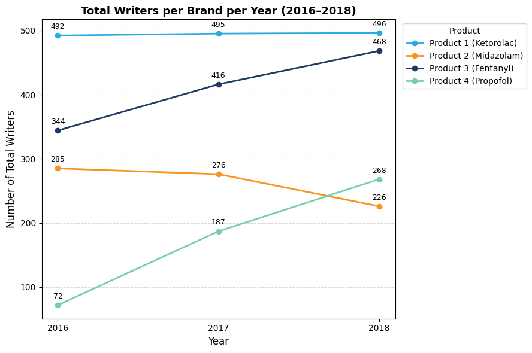

```python
# ── Total Writers per Brand per Year ─────────────────────────────────────────
# Define colors based on your palette
colors_list = ['#29ABE2', '#F7941D', '#1F3864', '#77CFA6']

fig, ax = plt.subplots(figsize=(9, 6))

# Map products to colors consistently
product_list = total_writers['product'].unique()
color_map = {product: colors_list[i % len(colors_list)] for i, product in enumerate(product_list)}

for product, grp in total_writers.groupby('product'):
    grp_sorted = grp.sort_values('claim_year')
    ax.plot(grp_sorted['claim_year'], grp_sorted['total_writers'],
            marker='o', linewidth=2, label=product, color=color_map[product])
    for _, row in grp_sorted.iterrows():
        ax.annotate(f"{int(row['total_writers'])}",
                    (row['claim_year'], row['total_writers']),
                    textcoords='offset points', xytext=(0, 8), ha='center', fontsize=9)

ax.set_xlabel('Year', fontsize=12)
ax.set_ylabel('Number of Total Writers', fontsize=12)
ax.set_title('Total Writers per Brand per Year (2016–2018)',
             fontsize=13, fontweight='bold')
ax.set_xticks([2016, 2017, 2018])
ax.legend(title='Product', bbox_to_anchor=(1.01, 1), loc='upper left')
ax.grid(axis='y', linestyle='--', alpha=0.5)

plt.tight_layout()
plt.savefig('kbq2_total_writers.png', dpi=150, bbox_inches='tight')
plt.show()
```

## Recommendation:

## KBQ3 — Strategic Recommendations to Stop Market Share Erosion for Product 2 (Midazolam)

**Observation 1** — Claims & Patient Share is eroding rapidly for Product 2 From the 100% stacked bar charts, Product 2's share of claims and patients has been declining year over year from 2016 to 2018, while Product 3 (Fentanyl) is consistently gaining share across both metrics. Product 1 still dominates but is also slowly declining.

Recommendation: Immediate sales force intervention is needed in territories where Product 2 is losing the most ground. Redirect promotional budget from low-performing territories to high-volume territories like New York, NY and LA-San Diego, CA where the absolute claim volumes are highest and the impact of recovery would be greatest.

Recommendation: Focus on writer activation — identify the existing writers who have reduced their prescribing frequency and deploy the sales force to re-engage them with clinical evidence and detailing. A targeted outreach program for lapsing writers should be a top priority.

**Observation 3** — Top 5 declining territories show Product 3 growing while Product 2 shrinks The clustered bar charts for the top 5 declining territories show that in every territory where Product 2 dropped sharply between 2017 and 2018, Product 3 simultaneously grew. This is a direct substitution pattern — HCPs are switching from Product 2 to Product 3.

Recommendation: For high-volume territories (e.g., New York, NY and LA-San Diego, CA) deploy additional sales reps and increase call frequency to top HCPs to defend existing writers. For lower-volume territories (e.g., Minneapolis, MN and Phoenix, AZ), consider non-personal promotions such as digital campaigns and peer-to-peer programs to cost-effectively maintain presence without heavy field investment.

Recommendation: Concentrate sales force efforts and speaker programs specifically on Anesthesiologists, as they are the highest-volume writers in this market. Any HCP targeting strategy should prioritize this specialty above all others for Product 2 detailing.

Recommendation: Tailor promotional messaging to emphasize Product 2's safety and efficacy profile for older patients, particularly around its anesthesia induction use case. Since this is the dominant patient segment, any clinical messaging should be specifically designed around outcomes relevant to this age group to resonate with prescribing HCPs.

## KBQ4 — Data Exploration Opportunities and Data Gaps

1. Sales Force Call Activity Data (Calls Data) The given dataset has no information on how frequently the sales force is detailing HCPs for Product 2. Without call activity data, we cannot measure whether the market share erosion is correlated with low sales force engagement or poor call quality. With calls data, we could build a call response model to identify the optimal call frequency per HCP segment and territory to maximize prescribing behavior for Product 2, and identify under-called high-potential HCPs who are currently writing Product 3.
2. Non-Personal Promotion (NPP) Response Data There is no data on digital, print, or speaker program promotions for Product 2 in this dataset. NPP data would allow us to measure the promotion response rate across different HCP segments and geographies, and determine whether non-personal channels are effectively complementing the field force. Given the collapsing new writer acquisition for Product 2, understanding which promotional channels are driving trial among new writers is critical.
3. DDD / NPA / NSP (Prescription and Sales Volume Data) The Medicare claims data only captures the Medicare population, which is a subset of the total market. DDD (Daily Defined Doses), NPA (National Prescription Audit), and NSP (National Sales Perspective) data would give a complete picture of total market volume across all payer types — commercial, Medicaid, and cash — not just Medicare. This is a significant data gap because Product 2's true market share erosion could be even worse or better than what the Medicare claims alone suggest.
4. Payer and Formulary / Market Access Data The dataset has no payer mix or formulary coverage information. A key reason Product 2 may be losing share to Product 3 could be formulary restrictions or prior authorization requirements imposed by payers that make Product 3 easier to prescribe. Without market access data, we cannot determine whether the decline is driven by clinical preference or by payer-level barriers that the sales force cannot overcome through detailing alone.
5. Missing Data Items Within the Claims Data Several important fields that are typically available in claims data are missing or unusable here. Specifically, the claim payment amount (clm_pmt_amt) and allowed charge amount fields have significant nulls, preventing any revenue or reimbursement analysis. Additionally, the clm_prvdr_spclty_cd (provider specialty code) is present but in numeric coded format with no mapping provided, making it unusable — a complete specialty code mapping table would have allowed a more granular HCP specialty analysis directly from the claims rather than relying solely on the HCP demographics file. Finally, there is no drug dosage or quantity field in the claims data, which would have allowed analysis of treatment intensity per patient per HCP — a key metric for understanding depth of product usage beyond just claim counts.

# SECTION 6: Bonus KBQ Analysis

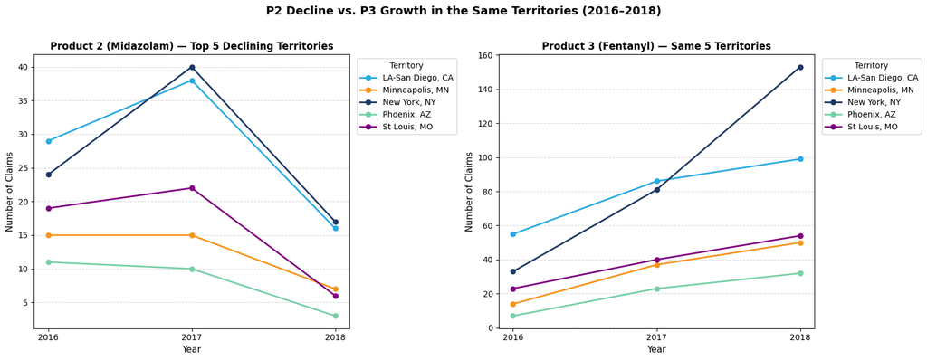

```python
fig, axes = plt.subplots(1, 2, figsize=(16, 6), sharey=False)

# Updated palette: Bright Blue, Orange, Dark Navy, Seafoam Green, Purple
line_colors = ['#29ABE2', '#F7941D', '#1F3864', '#77CFA6', '#800080']
years = [2016, 2017, 2018]

# P2 line chart
for i, territory in enumerate(p2_top5_pivot.columns):
    axes[0].plot(years, p2_top5_pivot[territory], marker='o', linewidth=2,
                 label=territory, color=line_colors[i])

axes[0].set_title('Product 2 (Midazolam) — Top 5 Declining Territories',
                  fontweight='bold', fontsize=12)
axes[0].set_xticks(years)
axes[0].set_xlabel('Year', fontsize=11)
axes[0].set_ylabel('Number of Claims', fontsize=11)
axes[0].legend(title='Territory', bbox_to_anchor=(1.01, 1), loc='upper left')
axes[0].grid(axis='y', linestyle='--', alpha=0.5)

# P3 line chart
for i, territory in enumerate(p3_top5_pivot.columns):
    axes[1].plot(years, p3_top5_pivot[territory], marker='o', linewidth=2,
                 label=territory, color=line_colors[i])

axes[1].set_title('Product 3 (Fentanyl) — Same 5 Territories',
                  fontweight='bold', fontsize=12)
axes[1].set_xticks(years)
axes[1].set_xlabel('Year', fontsize=11)
axes[1].set_ylabel('Number of Claims', fontsize=11)
axes[1].legend(title='Territory', bbox_to_anchor=(1.01, 1), loc='upper left')
axes[1].grid(axis='y', linestyle='--', alpha=0.5)

plt.suptitle('P2 Decline vs. P3 Growth in the Same Territories (2016–2018)',
             fontsize=14, fontweight='bold', y=1.02)
plt.tight_layout()
plt.savefig('kbq1_p2_vs_p3_lines.png', dpi=150, bbox_inches='tight')
plt.show()
```

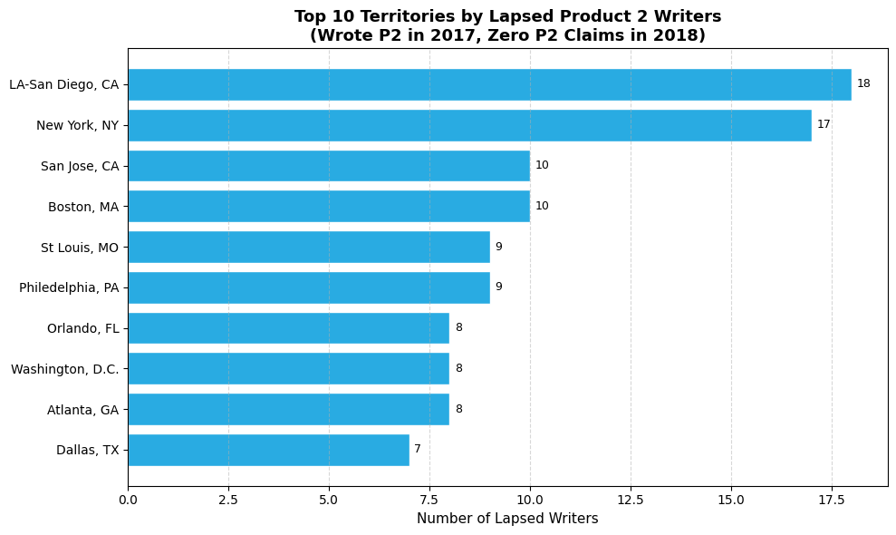

```python
fig, ax = plt.subplots(figsize=(10, 6))

# Sort ascending so highest value renders at top of horizontal bar chart
lapsed_sorted = lapsed_by_territory.sort_values('lapsed_writers', ascending=True)

# Replacing red with the first color in your palette: #29ABE2
bars = ax.barh(lapsed_sorted['Territory Name'],
               lapsed_sorted['lapsed_writers'],
               color='#29ABE2', edgecolor='white')

ax.bar_label(bars, fmt='%.0f', padding=4, fontsize=9)
ax.set_xlabel('Number of Lapsed Writers', fontsize=11)
ax.set_title('Top 10 Territories by Lapsed Product 2 Writers\n'
             '(Wrote P2 in 2017, Zero P2 Claims in 2018)',
             fontsize=13, fontweight='bold')
ax.grid(axis='x', linestyle='--', alpha=0.5)

plt.tight_layout()
plt.savefig('kbq3_lapsed_writers_territory.png', dpi=150, bbox_inches='tight')
plt.show()
```

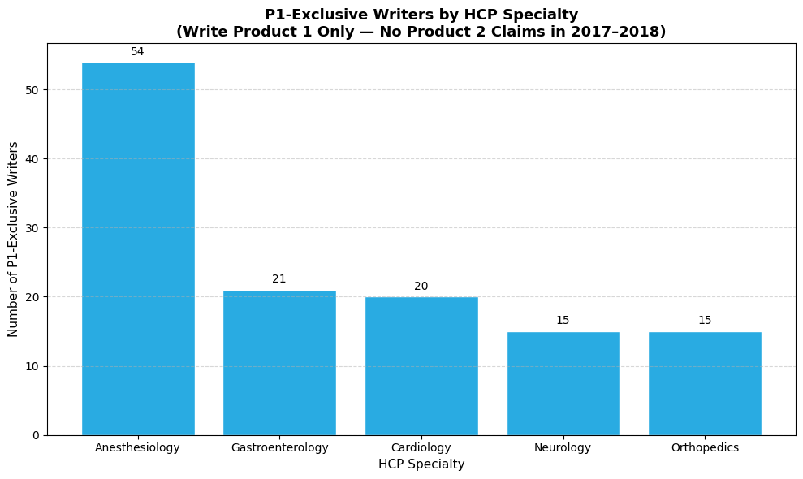

```python
fig, ax = plt.subplots(figsize=(10, 6))

specialty_counts = (
    p1_excl_df.groupby('Specialty_x')['fac_prvdr_npi_num']
    .nunique()
    .reset_index(name='p1_exclusive_writers')
    .sort_values('p1_exclusive_writers', ascending=False)
)

# Replacing orange with the first color in your palette: #29ABE2
bars = ax.bar(specialty_counts['Specialty_x'],
              specialty_counts['p1_exclusive_writers'],
              color='#29ABE2', edgecolor='white')

ax.bar_label(bars, fmt='%.0f', padding=4, fontsize=10)
ax.set_xlabel('HCP Specialty', fontsize=11)
ax.set_ylabel('Number of P1-Exclusive Writers', fontsize=11)
ax.set_title('P1-Exclusive Writers by HCP Specialty\n'
             '(Write Product 1 Only — No Product 2 Claims in 2017–2018)',
             fontsize=13, fontweight='bold')
ax.grid(axis='y', linestyle='--', alpha=0.5)

plt.tight_layout()
plt.savefig('kbq3_p1_exclusive_by_specialty.png', dpi=150, bbox_inches='tight')
plt.show()
```

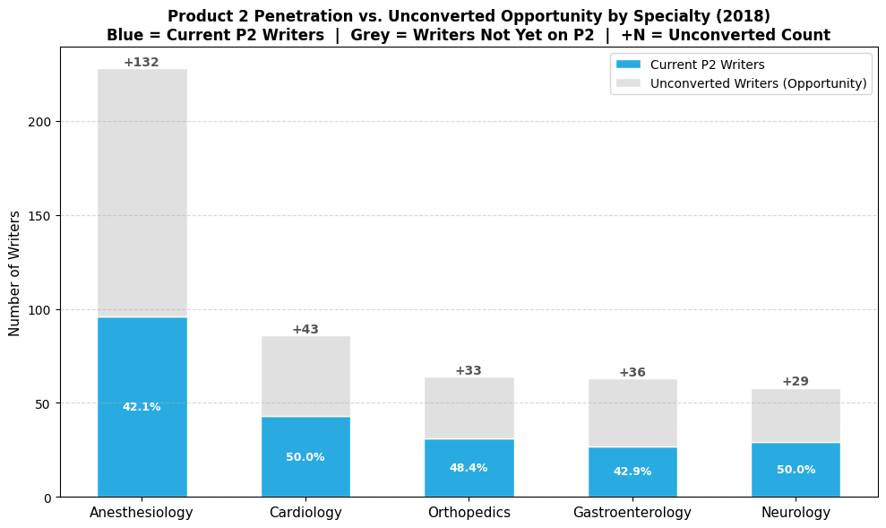

```python
fig, ax = plt.subplots(figsize=(10, 6))

specialties = penetration['Specialty_x']
total = penetration['total_writers'].values
p2 = penetration['p2_writers'].values
gap = total - p2

x = np.arange(len(specialties))
width = 0.55

# Updated to use the first color from your palette (Bright Blue)
bars_p2 = ax.bar(x, p2, width, label='Current P2 Writers', color='#29ABE2', edgecolor='white')
bars_gap = ax.bar(x, gap, width, bottom=p2, label='Unconverted Writers (Opportunity)',
                  color='#E0E0E0', edgecolor='white')

# Label the gap portion only (the opportunity)
for i, (g, p) in enumerate(zip(gap, p2)):
    ax.text(x[i], p + g + 1.5, f'+{int(g)}', ha='center', fontsize=10,
            fontweight='bold', color='#555555')

# Label penetration % inside the blue bar
for i, (pct, p) in enumerate(zip(penetration['p2_penetration_pct'], p2)):
    if p > 8:
        ax.text(x[i], p / 2, f'{pct}%', ha='center', va='center',
                fontsize=9, fontweight='bold', color='white')

ax.set_xticks(x)
ax.set_xticklabels(specialties, fontsize=11)
ax.set_ylabel('Number of Writers', fontsize=11)
ax.set_title('Product 2 Penetration vs. Unconverted Opportunity by Specialty (2018)\n'
             'Blue = Current P2 Writers  |  Grey = Writers Not Yet on P2  |  +N = Unconverted Count',
             fontsize=12, fontweight='bold')
ax.legend(loc='upper right', fontsize=10)
ax.grid(axis='y', linestyle='--', alpha=0.5)

plt.tight_layout()
plt.savefig('kbq3_p2_opportunity_gap.png', dpi=150, bbox_inches='tight')
plt.show()
```

### Diagnosis Breakdown - Zeroing in on Approach 2 Data

```python
# ── Diagnosis Breakdown: Circulatory System vs. All Others ───────────────────

import matplotlib.pyplot as plt
import matplotlib.ticker as mtick
import pandas as pd

# ── 1. Full diagnosis specialty breakdown (all years, all products) ───────────
diag_all = (
    market_df.groupby('Specialty_y')['claim_id']
    .count()
    .reset_index(name='claims')
    .sort_values('claims', ascending=False)
)
diag_all['pct'] = diag_all['claims'] / diag_all['claims'].sum() * 100
print("Full diagnosis specialty breakdown:")
print(diag_all.to_string(index=False))
```

```
Full diagnosis specialty breakdown:
                                                         Specialty_y  claims       pct
                                                  Circulatory System    7330 48.027781
  Factors Influencing Health Status and Contact with Health Services    1821 11.931595
              Symptoms, Signs and Abnormal Clinical and Lab Findings    1287  8.432709
                               Musculoskeletal and Connective Tissue    1195  7.829904
                                   Endocrine, Nutritional, Metabolic     762  4.992793
                                                    Digestive System     582  3.813393
                                                Genitourinary System     473  3.099201
                                                  Respiratory System     392  2.568471
                                     Mental and Behavioral Disorders     292  1.913249
                             Eye and Adnexa, Ear and Mastoid Process     249  1.631503
                              Neoplasms, Blood, Blood-forming Organs     228  1.493906
                                                      Nervous System     182  1.192504
    Injury, Poisoning, Certain Other Consequences of External Causes     160  1.048355
                                                           Neoplasms     137  0.897654
                                        Skin and Subcutaneous Tissue      90  0.589700
                                   Infectious and Parasitic Diseases      70  0.458655
                                        External Causes of Morbidity       7  0.045866
Congenital Malformations, Deformations and Chromosomal Abnormalities       5  0.032761
```

```python
# ── 2. Circulatory System: sub-diagnosis breakdown ────────────────────────────
# Show what ICD-10 codes sit beneath the Circulatory umbrella

circ_codes = market_df[market_df['Specialty_y'] == 'Circulatory System'].copy()

# First, how are these distributed across products?
circ_by_product = (
    circ_codes.groupby(['claim_year', 'product'])['claim_id']
    .count()
    .reset_index(name='claims')
)
print("\nCirculatory System claims by product and year:")
print(circ_by_product.to_string(index=False))
```

```
Circulatory System claims by product and year:
 claim_year               product  claims
       2016 Product 1 (Ketorolac)    1452
       2016 Product 2 (Midazolam)     215
       2016  Product 3 (Fentanyl)     388
       2016  Product 4 (Propofol)      65
       2017 Product 1 (Ketorolac)    1505
       2017 Product 2 (Midazolam)     212
       2017  Product 3 (Fentanyl)     554
       2017  Product 4 (Propofol)     187
       2018 Product 1 (Ketorolac)    1285
       2018 Product 2 (Midazolam)     162
       2018  Product 3 (Fentanyl)     966
       2018  Product 4 (Propofol)     339
```

```python
# ── 3. Top ICD-10 codes within Circulatory System ────────────────────────────
circ_icd = (
    circ_codes.groupby('diagnosis_code')['claim_id']
    .count()
    .reset_index(name='claims')
    .sort_values('claims', ascending=False)
    .head(15)
)
circ_icd['pct'] = circ_icd['claims'] / circ_icd['claims'].sum() * 100
print("\nTop 15 ICD-10 codes within Circulatory System:")
print(circ_icd.to_string(index=False))
```

```
Top 15 ICD-10 codes within Circulatory System:
diagnosis_code  claims       pct
           I10    6419 92.121125
         I4891     141  2.023536
          I739      57  0.818025
         I2510      52  0.746269
         I5033      41  0.588404
          I350      40  0.574053
          I509      34  0.487945
          I499      30  0.430540
         I4892      30  0.430540
          I252      28  0.401837
          I429      24  0.344432
          I480      21  0.301378
         I6340      21  0.301378
          I519      16  0.229621
         I4510      14  0.200918
```

```python
# ── 4. Circulatory System claims by product — are our products represented? ───
circ_product_total = (
    circ_codes.groupby('product')['claim_id']
    .count()
    .reset_index(name='claims')
    .sort_values('claims', ascending=False)
)
circ_product_total['pct'] = circ_product_total['claims'] / circ_product_total['claims'].sum() * 100
print("\nCirculatory System claims by product (all years):")
print(circ_product_total.to_string(index=False))
```

```
Circulatory System claims by product (all years):
              product  claims       pct
Product 1 (Ketorolac)    4242 57.871760
 Product 3 (Fentanyl)    1908 26.030014
 Product 4 (Propofol)     591  8.062756
Product 2 (Midazolam)     589  8.035471
```

```python
# Cell A — P2's diagnosis profile broken out vs. all other products
# We need to see where P2 is STRONGEST relative to competitors

for prod in market_df['product'].unique():
    sub = market_df[market_df['product'] == prod]
    profile = (
        sub.groupby('Specialty_y')['claim_id']
        .count()
        .reset_index(name='claims')
        .sort_values('claims', ascending=False)
    )
    profile['pct'] = profile['claims'] / profile['claims'].sum() * 100
    print(f"\n{'='*55}")
    print(f"{prod}")
    print('='*55)
    print(profile.head(6).to_string(index=False))
```

```
=======================================================
Product 3 (Fentanyl)
=======================================================
                                                       Specialty_y  claims       pct
                                                Circulatory System    1908 58.473797
Factors Influencing Health Status and Contact with Health Services     386 11.829605
            Symptoms, Signs and Abnormal Clinical and Lab Findings     187  5.730922
                             Musculoskeletal and Connective Tissue     183  5.608336
                                                  Digestive System     123  3.769537
                                 Endocrine, Nutritional, Metabolic     118  3.616304

=======================================================
Product 1 (Ketorolac)
=======================================================
                                                       Specialty_y  claims       pct
                                                Circulatory System    4242 41.805460
Factors Influencing Health Status and Contact with Health Services    1307 12.880654
            Symptoms, Signs and Abnormal Clinical and Lab Findings     991  9.766433
                             Musculoskeletal and Connective Tissue     896  8.830196
                                 Endocrine, Nutritional, Metabolic     576  5.676555
                                                  Digestive System     402  3.961762

=======================================================
Product 4 (Propofol)
=======================================================
                                                       Specialty_y  claims       pct
                                                Circulatory System     591 83.948864
Factors Influencing Health Status and Contact with Health Services      28  3.977273
            Symptoms, Signs and Abnormal Clinical and Lab Findings      21  2.982955
                                   Mental and Behavioral Disorders      13  1.846591
                                 Endocrine, Nutritional, Metabolic      12  1.704545
                                                Respiratory System      12  1.704545

=======================================================
Product 2 (Midazolam)
=======================================================
                                                       Specialty_y  claims       pct
                                                Circulatory System     589 51.306620
                             Musculoskeletal and Connective Tissue     105  9.146341
Factors Influencing Health Status and Contact with Health Services     100  8.710801
            Symptoms, Signs and Abnormal Clinical and Lab Findings      88  7.665505
                                 Endocrine, Nutritional, Metabolic      56  4.878049
                                                  Digestive System      48  4.181185
```

```python
# Cell B — Within the non-circulatory diagnoses only,
# what is each product's share? This isolates the terrain
# where P2 can actually compete.

non_circ = market_df[market_df['Specialty_y'] != 'Circulatory System'].copy()

non_circ_share = (
    non_circ.groupby(['product', 'Specialty_y'])['claim_id']
    .count()
    .reset_index(name='claims')
)
non_circ_share['pct_within_specialty'] = (
    non_circ_share.groupby('Specialty_y')['claims']
    .transform(lambda x: x / x.sum() * 100)
)

# Show product share within each non-circulatory specialty
pivot_noncirc = non_circ_share.pivot_table(
    index='Specialty_y', columns='product',
    values='pct_within_specialty', fill_value=0
).round(1)

total_by_spec = non_circ.groupby('Specialty_y')['claim_id'].count().rename('total_claims')
pivot_noncirc = pivot_noncirc.join(total_by_spec).sort_values('total_claims', ascending=False)
print(pivot_noncirc.to_string())
```

```
                                                                      Product 1 (Ketorolac)  Product 2 (Midazolam)  Product 3 (Fentanyl)  Product 4 (Propofol)  total_claims
Specialty_y
Factors Influencing Health Status and Contact with Health Services                     71.8                    5.5                  21.2                   1.5          1821
Symptoms, Signs and Abnormal Clinical and Lab Findings                                 77.0                    6.8                  14.5                   1.6          1287
Musculoskeletal and Connective Tissue                                                  75.0                    8.8                  15.3                   0.9          1195
Endocrine, Nutritional, Metabolic                                                      75.6                    7.3                  15.5                   1.6           762
Digestive System                                                                       69.1                    8.2                  21.1                   1.5           582
Genitourinary System                                                                   79.3                    7.0                  13.7                   0.0           473
Respiratory System                                                                     73.7                    4.6                  18.6                   3.1           392
Mental and Behavioral Disorders                                                        77.4                    4.8                  13.4                   4.5           292
Eye and Adnexa, Ear and Mastoid Process                                                76.3                    8.0                  14.9                   0.8           249
Neoplasms, Blood, Blood-forming Organs                                                 72.4                    7.5                  19.7                   0.4           228
Nervous System                                                                         77.5                    8.8                  13.2                   0.5           182
Injury, Poisoning, Certain Other Consequences of External Causes                       83.8                    2.5                  11.9                   1.9           160
Neoplasms                                                                              65.0                   18.2                  16.8                   0.0           137
Skin and Subcutaneous Tissue                                                           72.2                    6.7                  21.1                   0.0            90
Infectious and Parasitic Diseases                                                      72.9                   11.4                  15.7                   0.0            70
External Causes of Morbidity                                                           71.4                   14.3                  14.3                   0.0             7
Congenital Malformations, Deformations and Chromosomal Abnormalities                   60.0                    0.0                  40.0                   0.0             5
```

```python
# Cell C — HCPs who write P2 AND P3 vs. exclusively one or the other
# This tells us whether the competitive battle is happening at the
# same HCP or across different HCP populations entirely

p2_writers = set(market_df[market_df['product'] == 'Product 2 (Midazolam)']['fac_prvdr_npi_num'])
p3_writers = set(market_df[market_df['product'] == 'Product 3 (Fentanyl)']['fac_prvdr_npi_num'])
p1_writers = set(market_df[market_df['product'] == 'Product 1 (Ketorolac)']['fac_prvdr_npi_num'])

p2_only      = p2_writers - p3_writers - p1_writers
p3_only      = p3_writers - p2_writers - p1_writers
p2_and_p3    = p2_writers & p3_writers
p2_and_p1    = p2_writers & p1_writers
p3_and_p1    = p3_writers & p1_writers
all_three    = p2_writers & p3_writers & p1_writers
p3_not_p2    = p3_writers - p2_writers  # the highest-value conversion target

print(f"P2 exclusive writers:        {len(p2_only)}")
print(f"P3 exclusive writers:        {len(p3_only)}")
print(f"P2 and P3 (both):            {len(p2_and_p3)}")
print(f"P2 and P1 (both):            {len(p2_and_p1)}")
print(f"P3 and P1 (both):            {len(p3_and_p1)}")
print(f"All three products:          {len(all_three)}")
print(f"P3 writers never tried P2:   {len(p3_not_p2)}")
print(f"Total unique P2 writers:     {len(p2_writers)}")
print(f"Total unique P3 writers:     {len(p3_writers)}")
```

```
P2 exclusive writers:        0
P3 exclusive writers:        0
P2 and P3 (both):            428
P2 and P1 (both):            430
P3 and P1 (both):            495
All three products:          428
P3 writers never tried P2:   67
Total unique P2 writers:     430
Total unique P3 writers:     495
```

```python
# Cell D — Among the 428 shared writers (P2 AND P3),
# what is the trend in claims per writer for each product?
# This quantifies the share-of-wallet shift directly.

shared_writers = list(p2_writers & p3_writers)

shared_df = market_df[
    market_df['fac_prvdr_npi_num'].isin(shared_writers) &
    market_df['product'].isin(['Product 2 (Midazolam)', 'Product 3 (Fentanyl)'])
].copy()

shared_summary = (
    shared_df.groupby(['claim_year', 'product'])
    .agg(
        claims=('claim_id', 'count'),
        writers=('fac_prvdr_npi_num', 'nunique')
    )
    .reset_index()
)
shared_summary['claims_per_writer'] = (
    shared_summary['claims'] / shared_summary['writers']
).round(2)

print("Among 428 shared P2+P3 writers:")
print(shared_summary.to_string(index=False))
```

```
Among 428 shared P2+P3 writers:
 claim_year               product  claims  writers  claims_per_writer
       2016 Product 2 (Midazolam)     428      284               1.51
       2016  Product 3 (Fentanyl)     539      306               1.76
       2017 Product 2 (Midazolam)     416      275               1.51
       2017  Product 3 (Fentanyl)     939      361               2.60
       2018 Product 2 (Midazolam)     302      226               1.34
       2018  Product 3 (Fentanyl)    1425      407               3.50
```

```python
# Cell E — Within the 428 shared writers, which non-circulatory
# diagnosis specialties show P3 gaining on P2?
# These are the specific clinical settings to target.

shared_noncirc = shared_df[shared_df['Specialty_y'] != 'Circulatory System'].copy()

shared_diag_share = (
    shared_noncirc.groupby(['Specialty_y', 'product'])['claim_id']
    .count()
    .reset_index(name='claims')
)
shared_diag_share['pct'] = (
    shared_diag_share.groupby('Specialty_y')['claims']
    .transform(lambda x: x / x.sum() * 100)
)

shared_pivot = shared_diag_share.pivot_table(
    index='Specialty_y', columns='product',
    values='pct', fill_value=0
).round(1)

total_shared = shared_noncirc.groupby('Specialty_y')['claim_id'].count().rename('total_claims')
shared_pivot = shared_pivot.join(total_shared).sort_values('total_claims', ascending=False)
print("Non-circulatory diagnosis share within shared writers only:")
print(shared_pivot.to_string())
```

```
Non-circulatory diagnosis share within shared writers only:
                                                                      Product 2 (Midazolam)  Product 3 (Fentanyl)  total_claims
Specialty_y
Factors Influencing Health Status and Contact with Health Services                     22.4                  77.6           442
Musculoskeletal and Connective Tissue                                                  38.0                  62.0           276
Symptoms, Signs and Abnormal Clinical and Lab Findings                                 34.6                  65.4           254
Endocrine, Nutritional, Metabolic                                                      35.2                  64.8           159
Digestive System                                                                       30.6                  69.4           157
Genitourinary System                                                                   35.9                  64.1            92
Respiratory System                                                                     22.0                  78.0            82
Neoplasms, Blood, Blood-forming Organs                                                 30.4                  69.6            56
Eye and Adnexa, Ear and Mastoid Process                                                37.7                  62.3            53
Mental and Behavioral Disorders                                                        28.6                  71.4            49
Neoplasms                                                                              58.1                  41.9            43
Nervous System                                                                         42.1                  57.9            38
Skin and Subcutaneous Tissue                                                           26.1                  73.9            23
Injury, Poisoning, Certain Other Consequences of External Causes                       20.0                  80.0            20
Infectious and Parasitic Diseases                                                      42.1                  57.9            19
Congenital Malformations, Deformations and Chromosomal Abnormalities                    0.0                 100.0             2
External Causes of Morbidity                                                           50.0                  50.0             2
```

```python
# Cell F — For the 67 P3 writers who have never tried P2,
# what specialties do they practice in?
# These are the secondary acquisition targets.

p3_never_p2 = list(p3_not_p2)

p3_only_df = market_df[
    market_df['fac_prvdr_npi_num'].isin(p3_never_p2)
].copy()

p3_only_specialty = (
    p3_only_df.groupby('Specialty_x')['fac_prvdr_npi_num']
    .nunique()
    .reset_index(name='writers')
    .sort_values('writers', ascending=False)
)
print("HCP specialties of the 67 P3 writers who have never written P2:")
print(p3_only_specialty.to_string(index=False))

# Also check their diagnosis profile
p3_only_diag = (
    p3_only_df.groupby('Specialty_y')['claim_id']
    .count()
    .reset_index(name='claims')
    .sort_values('claims', ascending=False)
)
p3_only_diag['pct'] = p3_only_diag['claims'] / p3_only_diag['claims'].sum() * 100
print("\nDiagnosis profile of those 67 writers:")
print(p3_only_diag.head(8).to_string(index=False))
```

```
HCP specialties of the 67 P3 writers who have never written P2:
     Specialty_x  writers
  Anesthesiology       30
Gastroenterology       11
       Neurology       11
      Cardiology        9
     Orthopedics        6

Diagnosis profile of those 67 writers:
                                                       Specialty_y  claims       pct
                                                Circulatory System     793 49.193548
Factors Influencing Health Status and Contact with Health Services     185 11.476427
            Symptoms, Signs and Abnormal Clinical and Lab Findings     125  7.754342
                             Musculoskeletal and Connective Tissue     123  7.630273
                                 Endocrine, Nutritional, Metabolic      79  4.900744
                                                  Digestive System      62  3.846154
                                              Genitourinary System      42  2.605459
                                                Respiratory System      39  2.419355
```